# Homework 3: The Casino and Baseball

# Question 1

In the game of [roulette](https://en.wikipedia.org/wiki/Roulette) you can bet on several things including black or red. On this bet, if you win, you double your earnings. In this problem we will look at how the casino makes money on this. If you look at the [possibilities](http://www.math.uah.edu/stat/games/Roulette.png), you realize that the chance of red or black are both slightly less than 1/2. There are two green spots, so the probability of landing on black (or red) is actually 18/38, or 9/19.

### Question 1A

Let’s make a quick sampling model for this simple version of roulette. You are going to bet a dollar each time you play and always bet on black. Make a sampling model for this process using the `sample` function. Write a function `roulette` that takes as an argument the number of times you play, $n$, and returns your earnings, which here we denote with $S_n$.

```r
  # For later...
  library(dplyr)
```

```r
  library(tidyr)
  library(ggplot2)

  # Create roulette function
  roulette <- function(n){
    outcomes <- sample(c("Red", "Black", "Green"), n,
                       replace = TRUE, prob = c(18/38, 18/38, 2/38))
    earnings <- sum(outcomes == "Black") * 2
    return(earnings)
  }
```

### Question 1B

Use Monte Carlo simulation to study the distribution of total earnings $S_n$ for $n = 100, 250, 500, 1000$. That is, for each value of $n$, make one or more plots to examine the distribution of earnings. Examine the plots, and describe how the expected values and standard errors change with $n$. You do not need to show us the plots. Just the code you used to create them. Hints: It’s OK to use a for-loop. Think about the possible values $S_n$ can take when deciding on the `geom_histogram` parameters such as `binwidth` and `center`.

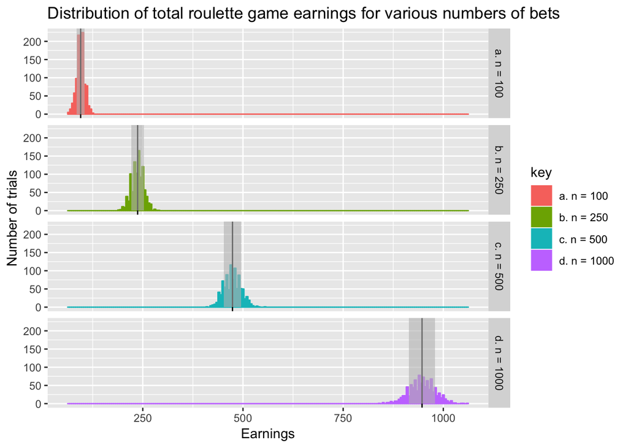

```r
  # Earnings over 1000 replications for each number of trials
  earned <- sapply(list("a. n = 100" = 100, "b. n = 250" = 250,
                        "c. n = 500" = 500, "d. n = 1000" = 1000),
                  function(n) replicate(1000, {roulette(n)})) %>% as.data.frame %>% gather

  # Get mean and SD of earnings distribution for plot
  summarystats <- group_by(earned, key) %>%
    summarise("Mean" = mean(value), "SD" = sd(value))

  # Plot the distribution of earnings for each number of trials
  ggplot(data = earned, aes(x = value, fill = key, col = key)) +
    geom_histogram(binwidth = 5, center = 0) +
    facet_grid(rows = key~.) +
    geom_vline(data = summarystats, aes(xintercept = Mean)) +
    geom_rect(data = summarystats, aes(xmin = Mean - SD, xmax = Mean + SD, x = NULL),
              ymin = 0, ymax = 400, alpha = 0.6, fill = "grey", col = NA) +
    xlab("Earnings") +
    ylab("Number of trials") +
    ggtitle("Distribution of total roulette game earnings for various numbers of bets")
```

The larger the value of n, the larger expected value of S_n (indicated by a black vertical line on the plot) and the larger the standard error of S_n (one standard error above and below the mean is shaded grey on the plot).

### Question 1C

Repeat Problem 1B but for the means instead of the sums. After your answer, describe the mathematical results that you can use to answer this without making plots.

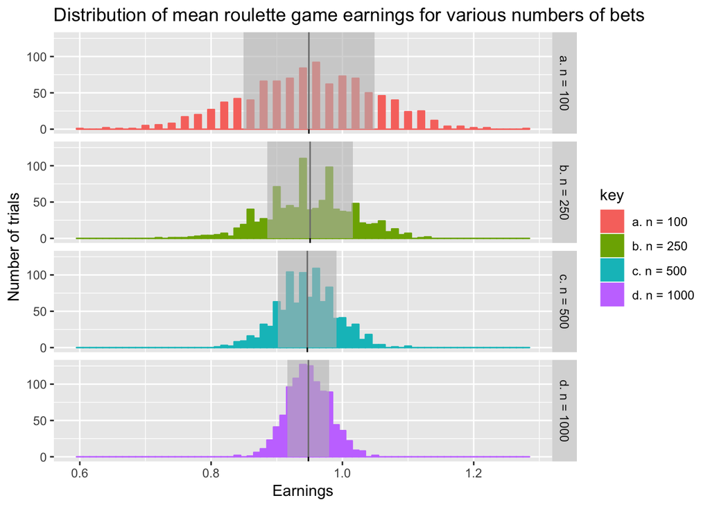

```r
    # 1000 replications for each numeber of trials
    earned_mean <- sapply(list("a. n = 100" = 100, "b. n = 250" = 250,
                          "c. n = 500" = 500, "d. n = 1000" = 1000),
                    function(n) replicate(1000, {roulette(n) / n})) %>%
                  as.data.frame %>% gather

    # Mean and standard deviation again
    summarystats_mean <- group_by(earned_mean, key) %>%
      summarise("Mean" = mean(value), "SD" = sd(value))

    # Plot the mean earnings
    ggplot(data = earned_mean, aes(x = value, fill = key, col = key)) +
      geom_histogram(binwidth = .010, center = 0) +
      facet_grid(rows = key~.) +
      geom_vline(data = summarystats_mean, aes(xintercept = Mean)) +
      geom_rect(data = summarystats_mean, aes(xmin = Mean - SD, xmax = Mean + SD, x = NULL),
                ymin = 0, ymax = 250, alpha = 0.6, fill = "grey", col = NA) +
      xlab("Earnings") +
      ylab("Number of trials") +
      ggtitle("Distribution of mean roulette game earnings for various numbers of bets")
```

In this case, the expected values are all the same (the means themselves are similar but not identical due to sampling variation) and the standard error gets smaller with larger numbers of draws.

If we wanted to determine these values mathematically we could first calculate the expected value of the sum of earnings for a given number of draws:
$$(\frac{18}{38} \times \$ 2) \times n=\$0.9473 \times n$$

We can also get the standard deviation of the earnings:
$$|2-0|\times \sqrt{\frac{18}{38}\times\frac{20}{38}}=0.9986$$

And use the standard deviation to get the standard error of the sum of the earnings:
$$\sqrt{n} \times 0.9986$$

We see that the expected value of the sum is a positive constant times n, so it makes sense that we saw the expected value of the sum getting larger as n increased. We also see that the standard error of the sum is a constant (less than 1) times the square root of n, so again it makes sense that the standard error of the sum got larger as n increased.

However, now we are interested in the expected value and standard error of the mean rather than the sum. The mean is just the sum divided by n, and we know that the standard error of a random variable times a constant is just the random variable’s standard error times a constant, so our new standard error for the mean is:

$$\frac{\sqrt{n} \times 0.9986}{n} =\frac{.9986}{\sqrt{n}}$$

We see that the standard error will be smaller for larger n.

This no longer depends on n, so it is the same regardless of the number of trials.

### Question 1D

Now think of a sampling model for our casino problem. What is the expected value of our sampling model? What is the standard deviation of our sampling model?

Standard deviation:
$$SD(Earnings_n) = |-1-1|\times \sqrt{\frac{20}{38}\times\frac{18}{38}}=2\times0.4993=0.9986$$

### Question 1E

Suppose you play 100 times. Use the Central Limit Theorem (CLT) to approximate the probability that the casino loses money. Then use a Monte Carlo simulation to corroborate your finding.

```r
  # Using our mean and SD from above, for 100 rounds,
  # and using the CLT to assume normal distribution
  pnorm(0,
        mean = ((18/38)-(20/38)) * 100,
        sd = 2*sqrt((20/38)*(18/38)) * sqrt(100),
        lower.tail = FALSE)
```

```
## [1] 0.2990807
```

```r
  # Monte Carlo simulation using a version of the function we created earlier,
  # but for the casino's net gain/loss rather than player's earnings
  casino_earnings <- function(n){
    outcomes <- sample(c("Red", "Black", "Green"), n,
                       replace = TRUE, prob = c(18/38, 18/38, 2/38))
    # Casino gets a dollar for each bet and pays out $2 for each black spin
    earnings <- sum(outcomes == "Black") * -2 + n
    return(earnings)
  }
  # Run the function 1000 times, return TRUE (1) if casino loses money
  # and take the mean of the results
  mean(replicate(1000, {casino_earnings(100) < 0}))
```

```
## [1] 0.266
```

Indeed, we see similar results from the CLT approximation and the Monte Carlo simulation. The results are not exactly the same since the CLT is only asymptotically correct and we only had 100 trials.

### Question 1F

In general, what is the probability that the casino loses money as a function of $n$? Make a plot for values ranging from 25 to 1,000. Why does the casino give you free drinks if you keep playing?

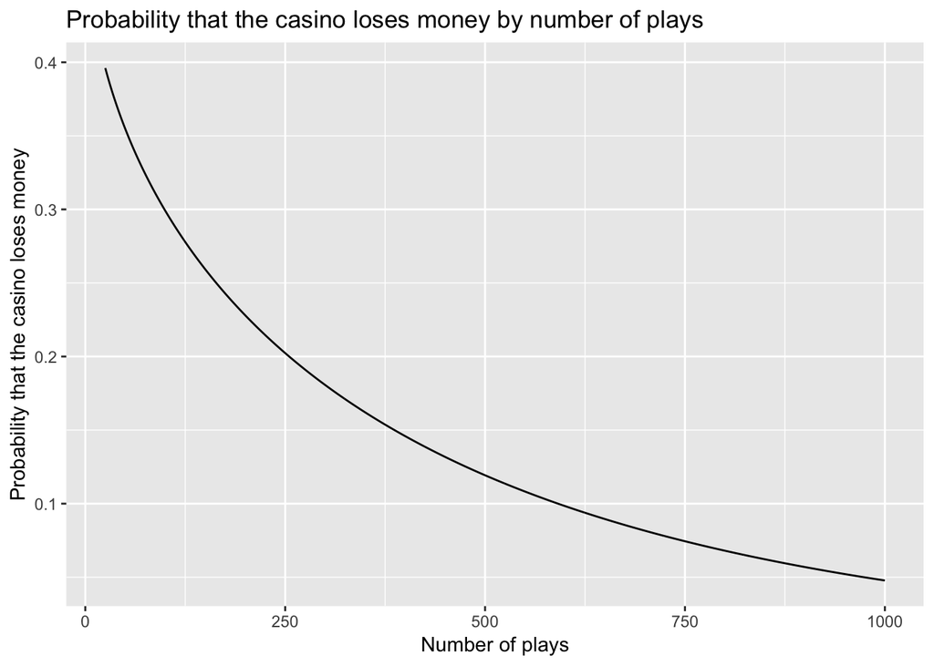

```r
  # Relying on the CLT, use the normal distribution to
  # approximate probabilities for 25 to 100 plays
  p_of_n <- sapply(25:1000, function(n) {pnorm(0,
        mean = ((18/38)-(20/38)) * n,
        sd = 2*sqrt((20/38)*(18/38)) * sqrt(n),
        lower.tail = FALSE)}) %>% data.frame(n = 25:1000, p = .)

  # Plot our probabilities
  ggplot(data = p_of_n, aes(x = n, y = p)) +
    geom_line() +
    ylab("Probability that the casino loses money") +
    xlab("Number of plays") +
    ggtitle("Probability that the casino loses money by number of plays")
```

The casino wants players to play more rounds because the casino’s probability of losing money declines as more rounds are played!

# Question 2

The baseball playoffs are about to start. During the first round of the playoffs, teams play a best of five series. After the first round, they play seven game series.

### Question 2A

The Red Sox and Astros are playing a five game series. Assume they are equally good. This means each game is like a coin toss. Build a Monte Carlo simulation to determine the probability that the Red Sox win the series. (Hint: start by creating a function `series_outcome` similar to the `roulette` function from Problem 1A.)

```r
  # Function for the series winner
  series_outcome <- function(n, prob_sox) {
    winner <- sample(c("Red Sox", "Astros"),
                     n, replace = TRUE, prob = c(prob_sox, 1 - prob_sox))
    team <- names(table(winner))[which(table(winner) > n/2)]
    return(team)
  }

  # Simulate the series 1000 times with equal teams
  mean(replicate(1000, {series_outcome(5, .5) == "Red Sox"}))
```

```
## [1] 0.506
```

### Question 2B

The answer to Problem 2A is not surprising. What if one of the teams is better? Compute the probability that the Red Sox win the series if the Astros are better and have a 60% of winning each game.

```r
  # Monte Carlo simulation with unequal teams
  mean(replicate(1000, {series_outcome(5, .4) == "Red Sox"}))
```

```
## [1] 0.329
```

```r
  # Or from the binomial distribution
  pbinom(2, 5, prob = 0.4, lower.tail = FALSE)
```

```
## [1] 0.31744
```

### Question 2C

How does this probability change if instead of five games, they play seven? How about three? What law did you learn that explains this?

```r
  # Seven game series simulation
  mean(replicate(1000, {series_outcome(7, .4) == "Red Sox"}))
```

```
## [1] 0.286
```

```r
  # Or seven-game series from the binomial distribution
  pbinom(3, 7, prob = 0.4, lower.tail = FALSE)
```

```
## [1] 0.289792
```

```r
  # Three game series simulation
  mean(replicate(1000, {series_outcome(3, .4) == "Red Sox"}))
```

```
## [1] 0.345
```

```r
  # Or three-game series from the binomial distribution
  pbinom(1, 3, prob = 0.4, lower.tail = FALSE)
```

```
## [1] 0.352
```

The probability is lower with more (7) games and higher with fewer (3) games. This corresponds to the law of large numbers, which tells us that as the number of draws (games) increases, the average of the draws converges to the average of the probability distribution, which in this case is 0.40. This means that the proportion of games the Red Sox win converges on 40%, which means that their probability of winning the series (which requires winning more than half of the games) gets lower and lower.

### Question 2D

Now, assume again that the two teams are equally good. What is the probability that the Red Sox still win the series if they lose the first game? Do this for a five game and seven game series.

```r
  # Five-game series: need to win three of four remaining games
  pbinom(2, 4, prob = 0.5, lower.tail = FALSE)
```

```
## [1] 0.3125
```

```r
  # Seven-game series: need to win four of six remaining games
  pbinom(3, 6, prob = 0.5, lower.tail = FALSE)
```

```
## [1] 0.34375
```